# MTH 530: iLab 3

Eric Stevens

November 15, 2018

### Environment Setup

```r
library(tidyverse)
library(infer)
library(skimr)
library(broom)
```

### Data

```r
# DATA PATH CHANGED HERE TO WORK WITH MY SETU{}
mercury <- read_csv(here::here("OHSU_Fall_2018/MATH530/iLabs", "fishermen_mercury.csv"),
                    col_types = cols(
                      fisherman = col_factor(levels = NULL))
                    )
```

Variables in this dataset include:

- Fisherman indicator (fisherman)
- Age in years (age)
- Residence Time in years (restime)
- Height in cm (height)
- Weight in kg (weight)
- Fish meals per week (fishmlwk)
- Parts of fish consumed:
  - 0=none,
  - 1=muscle tissue only,
  - 2=mt and sometimes whole fish,
  - 3=whole fish (fishpart)
- Methyl Mercury in mg/g (methyl_mercury)
- Total Mercury in mg/g (total_mercury)

### EDA

```r
glimpse(mercury)
```

```
Observations: 135
Variables: 9
$ fisherman      <fct> 1, 1, 1, 1, 1, 1, 1, 1, 1, 1, 1, 1, 1, 1, 1, 1, 1, 1,...
$ age            <int> 45, 38, 24, 41, 43, 58, 45, 46, 46, 46, 35, 25, 35, 4...
$ restime        <int> 6, 13, 2, 2, 11, 2, 6, 0, 14, 5, 2, 2, 0, 12, 1, 4, 1...
$ height         <int> 175, 173, 168, 183, 175, 176, 184, 170, 175, 175, 175...
$ weight         <int> 70, 73, 66, 80, 78, 75, 85, 68, 80, 75, 76, 66, 66, 8...
$ fishmlwk       <int> 14, 7, 7, 7, 21, 21, 21, 7, 21, 7, 21, 21, 21, 7, 7, ...
$ fishpart       <int> 2, 1, 2, 1, 1, 1, 1, 2, 1, 1, 2, 2, 2, 2, 2, 2, 2, 2,...
$ methyl_mercury <dbl> 4.011, 4.026, 3.578, 10.988, 10.520, 6.169, 17.214, 4...
$ total_mercury  <dbl> 4.484, 4.789, 3.856, 11.435, 10.849, 6.457, 17.788, 4...
```

```r
mercury %>%
  group_by(fisherman) %>%
  skim()
```

```
Skim summary statistics
 n obs: 135
 n variables: 9
 group variables: fisherman

── Variable type:integer ────────────────────────────────────────────────────────
 fisherman variable missing complete   n   mean   sd  p0 p25   p50   p75 p100
         1      age       0      100 100  34.92 8.92  16  28  33    42     58
         1 fishmlwk       0      100 100   8.45 4.85   3   7   7     7     21
         1 fishpart       0      100 100   1.9  0.52   1   2   2     2      3
         1   height       0      100 100 174.16 7.64 154 170 173.5 180    195
         1  restime       0      100 100   5.36 5.8    0   1   3    11     25
         1   weight       0      100 100  72.8  7.01  59  68  72.5  76     92
         0      age       0       35  35  30.43 2.6   26  28  30    32     35
         0 fishmlwk       0       35  35   1.03 0.79   0   0   1     2      2
         0 fishpart       0       35  35   1.17 0.86   0   0   1     2      2
         0   height       0       35  35 175.14 3.57 170 174 175   178.5  180
         0  restime       0       35  35   2.4  0.55   1   2   2     3      3
         0   weight       0       35  35  74.17 5.57  61  70  74    78     84
     hist
 ▁▆▇▇▃▅▂▁
 ▂▇▁▁▁▁▁▁
 ▂▁▁▇▁▁▁▁
 ▁▂▁▇▅▅▂▁
 ▇▂▁▁▂▁▁▁
 ▃▆▇▇▅▂▂▁
 ▃▇▆▆▂▆▂▇
 ▆▁▁▇▁▁▁▆
 ▅▁▁▅▁▁▁▇
 ▃▁▁▇▁▁▁▅
 ▁▁▁▇▁▁▁▆
 ▁▂▃▇▇▆▂▅

── Variable type:numeric ────────────────────────────────────────────────────────
 fisherman       variable missing complete   n mean   sd    p0  p25  p50  p75
         1 methyl_mercury       0      100 100 4.02 3.13 0.019 2.09 3.46 4.97
         1  total_mercury       0      100 100 4.18 3.22 0.025 2.24 3.73 5.13
         0 methyl_mercury       0       35  35 2.56 1.39 0.73  1.06 2.37 3.59
         0  total_mercury       0       35  35 2.62 1.4  0.74  1.13 2.48 3.65
  p100     hist
 17.21 ▅▇▅▁▁▁▁▁
 17.79 ▅▇▅▁▁▁▁▁
  5.11 ▇▁▆▃▃▂▂▃
  5.21 ▇▁▃▆▂▂▂▃
```

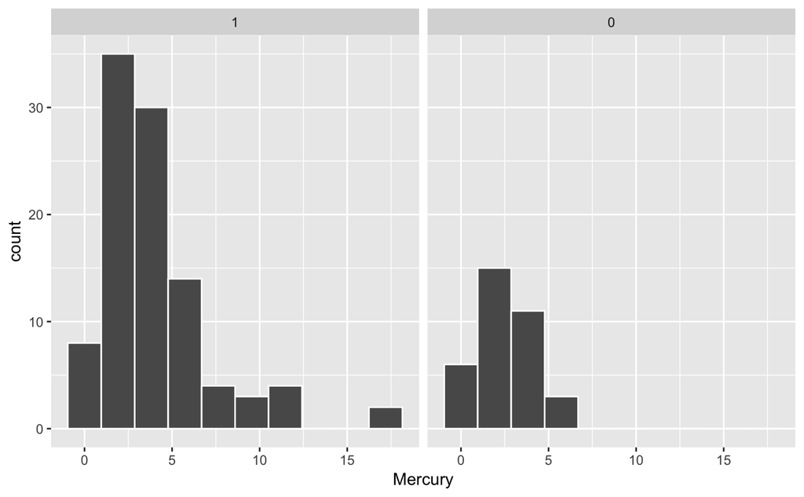

```r
ggplot(mercury, aes(x=methyl_mercury)) +
  geom_histogram(bins = 10, color='white') +
  labs(x = "Mercury") +
  facet_wrap(~fisherman)
```

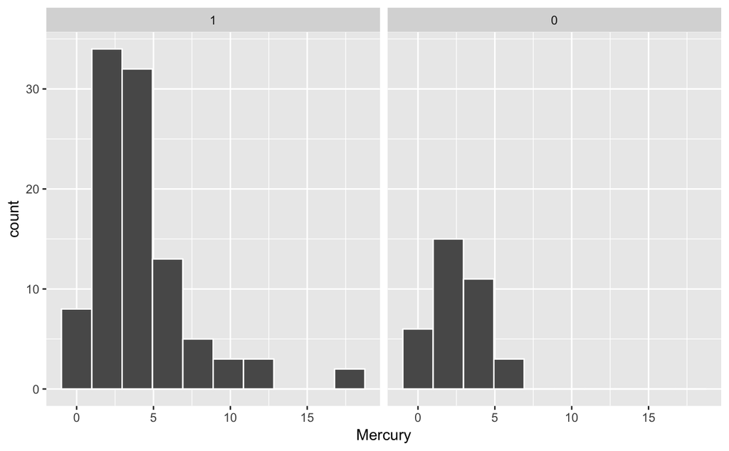

```r
ggplot(mercury, aes(x=total_mercury)) +
  geom_histogram(bins = 10, color='white') +
  labs(x = "Mercury") +
  facet_wrap(~fisherman, )
```

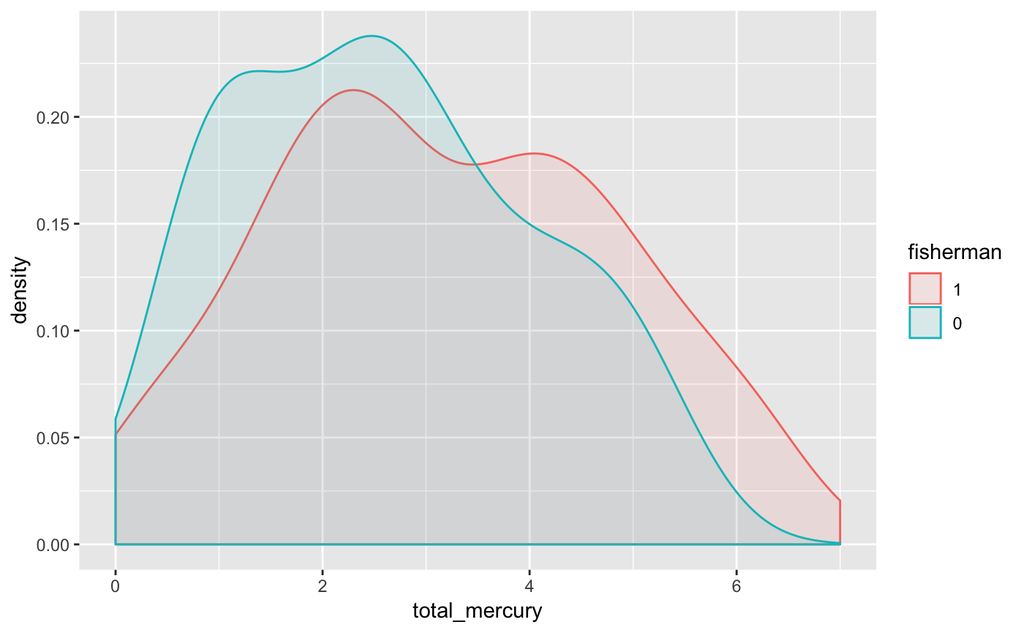

```r
ggplot(mercury, aes(total_mercury, fill = fisherman, colour = fisherman)) +
  geom_density(alpha = 0.1) +
  xlim(0, 7)
```

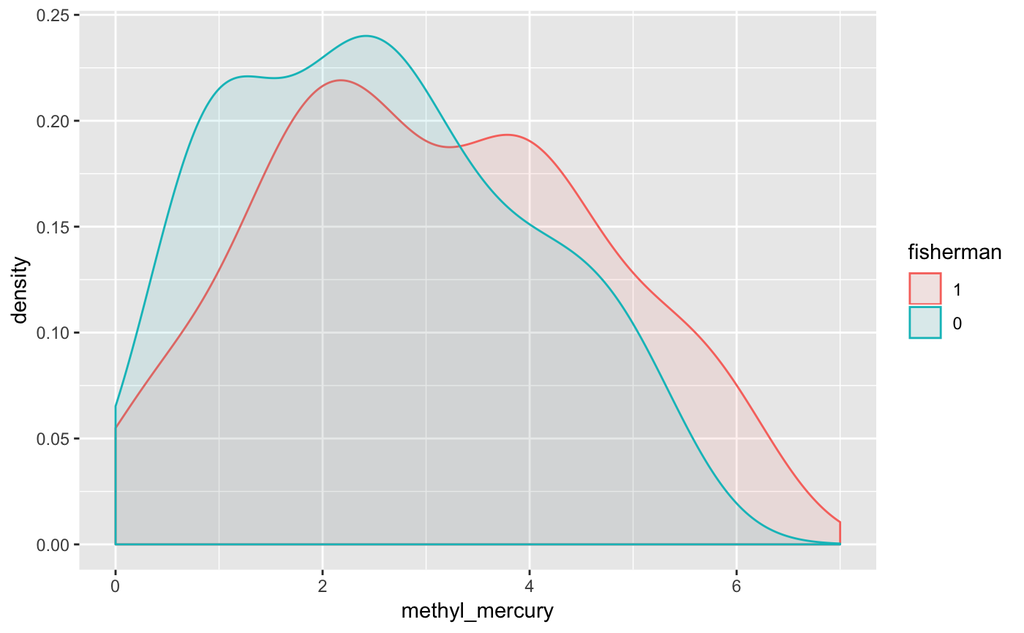

```r
ggplot(mercury, aes(methyl_mercury, fill = fisherman, colour = fisherman)) +
  geom_density(alpha = 0.1) +
  xlim(0, 7)
```